# 项目报告6：

## 统计学：检验心理学现象

## 目录

> 关于项目背景

> 调查问题的提出

> 描述性统计和可视化揭示了什么？

> 推断统计学工具的应用

> 结论

## 关于项目背景

> 本次项目将要探讨的是关于心理学上一个著名的实验--斯特鲁普效应。  
> 该心理学现象最早由美国心理学家约翰.斯特鲁普于1935年提出，他指出：当人们接收到一个新的信息，并且该信息与原先的信息相似或者一致，人们的认知反应速度便会加快；反而，如果人们接收到的新刺激信息与与原有的刺激信息不一致，那么人们的认知能力会受到干扰，从而会导致判断错误或者花费更长时间来做出判断。  
> 斯特鲁普实验则是通过给参与者看一些用不同颜色油墨打印的文字，这些文字中有些其文字内容与打印颜色一致（比如用橙色油墨打印的“橙色”两字），有些则是内容与打印颜色不一致（比如用绿色油墨打印的“红色”二字），记录下参与者说出文字打印颜色的时间，以考察参与者的抑制认知干扰的能力。  
> 此处我们有一组斯特鲁普实验的数据，我们将通过其来探索，当文字内容与文字的打印颜色不一致时，实验参与者是否真的要花更长时间来做出判断？抑或这只是偶然误差？

```python
#载入相关库
import numpy as np
import pandas as pd
import matplotlib.pyplot as plt
import seaborn as sns
import scipy.stats as stats
% matplotlib inline
```

```python
#读取数据集
df=pd.read_csv("stroopdata.csv")
```

```python
#简单查看数据集
print (df.shape)
df.head()
```

```
(24, 2)
```

|  | Congruent | Incongruent |
| --- | --- | --- |
| 0 | 12.079 | 19.278 |
| 1 | 16.791 | 18.741 |
| 2 | 9.564 | 21.214 |
| 3 | 8.630 | 15.687 |
| 4 | 14.669 | 22.803 |

## 调查问题的提出

> 为了厘清思路，我们提出以下几个问题，并尝试做一些简单回答。

> 该项目要探讨的问题是什么？

> 我们要探索的问题是，当文字内容与文字的打印颜色不一致时，实验参与者是否真的要花更长时间来做出判断？

> 该问题对应的自变量和因变量分别是什么？

> 显然，自变量是文字内容与其打印颜色是否一致，而因变量是实验参与者在两种不同情形下说出文字颜色所需时间。

> 使用什么方法来探讨两者是否存在差异？

> 我们将通过描述性统计和可视化的方法来呈现两者之间的差异。

> 上述步骤中，我们已经查看过该数据集的大体情况，该如何尽量避免因为样本量有限及偶然误差的存在而做出不准确的判断？

> 将会利用推断统计学的检验工具，来判断我们的推断在多大程度上是可靠的。

## 描述性统计和可视化揭示了什么？

### 描述性的统计指标

```python
#查看两种情形之下，数据的描述性统计指标
df.describe()
```

|  | Congruent | Incongruent |
| --- | --- | --- |
| count | 24.000000 | 24.000000 |
| mean | 14.051125 | 22.015917 |
| std | 3.559358 | 4.797057 |
| min | 8.630000 | 15.687000 |
| 25% | 11.895250 | 18.716750 |
| 50% | 14.356500 | 21.017500 |
| 75% | 16.200750 | 24.051500 |
| max | 22.328000 | 35.255000 |

> 从上述的描述性统计结果来看：  
> **平均值方面，一致的情况（Congruent）的平均值方面是14.05，看起来远小于不一致情况（Incongruent）的22.01。**平均值对于数据变化更敏感，有时候用于洞察关系会很适合，但此处我们更关注于把握两个样本的大体情况，平均值可能会被极端值所影响，因此我们再看一下中位数。  
> **中位数也是呈现出类似的情况：一致情形的中位数是14.36，而不一致情形下的中位数是21.02，与平均值的结果基本一致**，这两个指标都显示相比于一致的条件下，在不一致条件下人们要花费更长时间来做判断，文字内容与打印颜色的不一致会干扰人们的影响判断。  
> 另一方面，由于平均值和中位数都只是数据中的一个点，而我们要进一步从区间角度看数据，了解两组数据大体上是怎么分布的，以更好地判断两种情形下的差异。  
> 上四分位数和下四分位数之间集中了中间的50%数据，利用上四分位数与下四分位数之间的区间的差异来探讨两者的区别。可以看到的是，**一致情形该区间是11.90-16.20，而不一致情形下该区间则是18.71-24.05，不一致条件下的下四分位数就已经高于一致条件下的上四分位数，两个区间没有重合之处。这表明从中间的50%的数据来看，不一致条件下的用时是明显多于一致条件下的。**  
> **据切比雪夫不等式，平均值左右两个标准差的范围内至少包含了75%的数据，此处一致条件下均值前后两个标准差的范围是6.93-21.17，而不一致条件下该范围是12.42-31.61，虽然两者的该区间有重合之处，但仍可看出不一致条件总体上同时要比一致条件下更多。**

### 可视化的展示

#### 平均值与中位数的可视化

```
Text(0.5,0,'Condition')
```

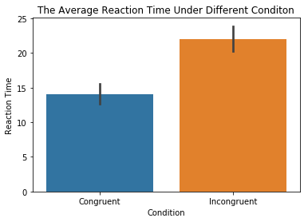

```python
sns.barplot(data=df);
plt.title("The Average Reaction Time Under Different Conditon")
plt.ylabel("Reaction Time")
plt.xlabel("Condition")
```

#### 数据分布的可视化

```
Text(0,0.5,'Reaction Time')
```

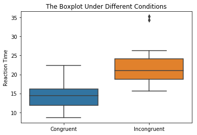

```python
#使用箱线图展示两份数据的分布差异
sns.boxplot(data=df);
plt.title("The Boxplot Under Different Conditions")
plt.ylabel("Reaction Time")
```

> 几乎上述所有的描述统计以及可视化展示都在阐明，在文字内容与打印颜色不一致的情况下，实验参与者们要花费更长的时间来做出判断。  
> 但这完全有可能只是我们这个样本的偶然误差所致，我们并不能就此急着下结论说两者之间就是真的有差异。

## 推断统计学工具的应用

> 我们假设一致条件下总体的平均反应时间为$\mu_1$，不一致条件下总体的平均反应时间为$\mu_2$，则：

#### 零假设：

> 我们令零假设为两种情况下平均做出反应花费的时长没有区别或一致条件下平均花费的时间更长，则零假设为：
> $$H_0:\mu_1\geq\mu_2$$

#### 备择假设：

> 备择假设需要于原假设互斥，则备择假设为一致条件下人们的平均反应时间更短，则备择假设为：
> $$H_1:\mu_1<\mu_2$$

#### 选用检验方式

> 由于我们对总体参数未知，同时样本量较少，只有24人的数据，因此将选用适合小样本的t检验。由于这是一组样本（同一批人）在不同条件下的测试结果，因此选用**配对样本t检验**比较合适。

#### 自由度的确定

> 自由度指的是取值不受限制的变量个数。此处是配对样本，以实验参与者在两种不同条件下的反应时间之差为变量，在样本均值已确定的约束条件下，只要确定前23个的值，最后一个的值也会随之确定（样本容量总共24）。因此自由度是n-1=24-1=23.

#### 显著性水平与置信水平的确定

> 设定显著性水平为5%，则置信水平为1-5%=95%

#### 用scipy库进行t假设检验

```python
stats.ttest_rel(df["Congruent"],df["Incongruent"])
```

```
Ttest_relResult(statistic=-8.020706944109957, pvalue=4.1030005857111781e-08)
```

#### t检验结果的解读

> 从上述的输出结果可以看到：  
> t统计量：-8.020706944109957  
> p-值：4.1030005857111781e-08  
> 由官方文档可知，scipy库的该函数是默认为双尾检验的，而我们的假设需要单边检验。  
> 由于我们的零假设是$H_0:\mu_1\geq\mu_2$，因此我们的检验应当是拒绝域位于t分布左部尾侧的单边检验，而非拒绝域位于两侧尾部的双尾检验。  
> **通过查询[t值表](https://github.com/ShiChJ/DAND-Basic-Materials/blob/master/P1/t-table.jpg)可知，$t_{0.05}(23)$=1.714，则我们可以算出t临界点为：$t_{1-0.05}(23)$=-1.714。由于t统计值-8.020706944109957<-1.714，落入拒绝域内，因此可以拒绝原假设，接受备择假设，认为一致条件下人们的应答时间要小于不一致条件。**

## 结论

> 从描述性统计和可视化展示中，我们可以初步得出文字内容与打印颜色不一致会干扰人们的判断，导致人们需要花费更长时间来给出回答。但仅从描述性统计和可视化的结果无法排除这些情况是偶然误差造成的。而通过假设检验后，我们可以认为该结论（即认为不一致的条件对参与者有干扰，导致平均做出判断时间更长）有95%以上的概率是可靠的。 因此我们可以认为不一致的条件对参与者有干扰。

## 参考资料：

[1] 维基百科.斯特鲁普效应[OL]https://zh.wikipedia.org/wiki/%E6%96%AF%E7%89%B9%E9%B2%81%E6%99%AE%E6%95%88%E5%BA%94  
[2] 西内启.统计思维[M]杭州：浙江人民出版社，2017.7  
[3] 百度百科.自由度[OL]https://baike.baidu.com/item/%E8%87%AA%E7%94%B1%E5%BA%A6/5936984?fr=aladdin